### Geocentric Models:

Linear Regression: An Attempt to learn the mean and variance of some measurement, using an additive combination of other measurements.

Why normal distributions are normal? : Let’s try and make the soccer field example:

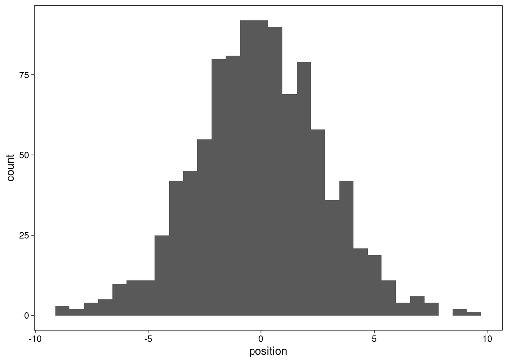

```r
tibble(
  position = replicate(1000,sum(runif(24, -1, 1)))
) %>%
  ggplot(aes(x = position))+
  geom_histogram( bins = 30)
```

Let’s now code the random walk:

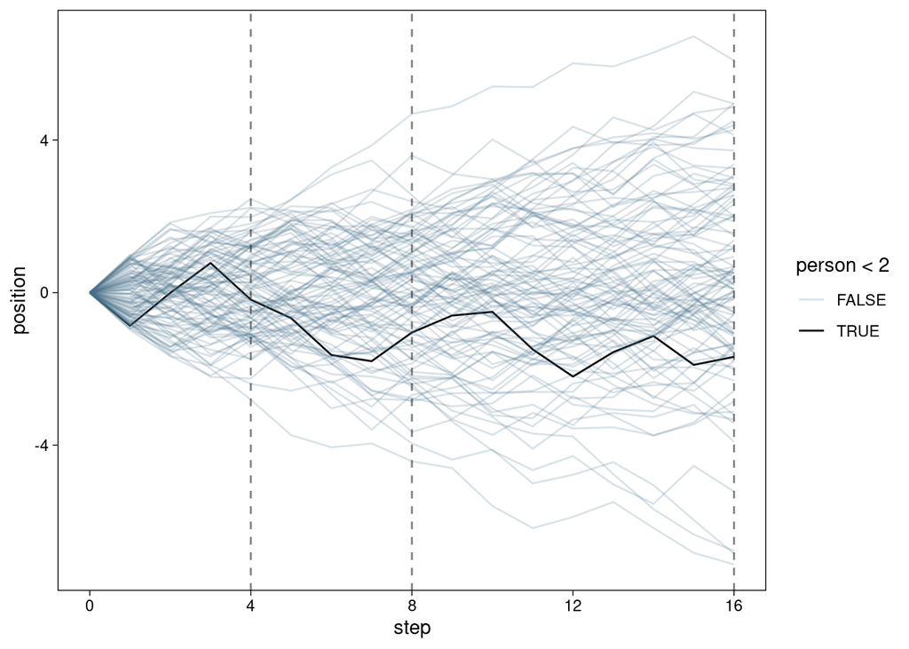

```r
#I want a 100 people's each of 16 position:
pos <- crossing(
  person = 1:100,
  step = 0:16,
) %>% mutate(
  deviation = map_dbl(step, ~ifelse(. == 0,0, runif(1, -1, 1)))
  ) %>% group_by(person) %>%
  mutate(position = cumsum(deviation)) %>%
  ungroup()

#Let's plot this:
pos %>%
  ggplot(aes(x = step,  y = position, group = person))+
  geom_line(aes(color = person <2, alpha = person < 2))+
  scale_color_manual(values = c("skyblue4", "black"))+
  scale_alpha_manual(values = c(1/5, 1))+
  geom_vline(xintercept = c(4, 8,16), alpha = 0.5, linetype = 2)+
  scale_x_continuous(breaks = 0:4 * 4)
```

Normality is essentially the result of additivity. Take any distribution and generate values from it, a more likely scenario is that values that deviate from the mean in one direction are cancelled out by values that deviate in another and what we are left with is more ways their cumulative sum approaches or lands in zero. This happens to any and all underlying distributions.

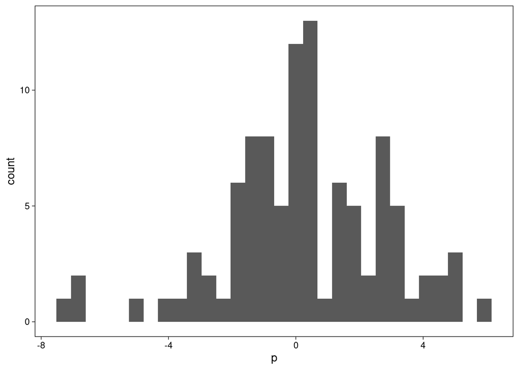

```r
#Let's look at the histogram:
pos %>%
  group_by(person) %>%
  summarise(p = sum(deviation)) %>%
  ggplot(aes(x = p)) +
  geom_histogram(bins = 30)
```

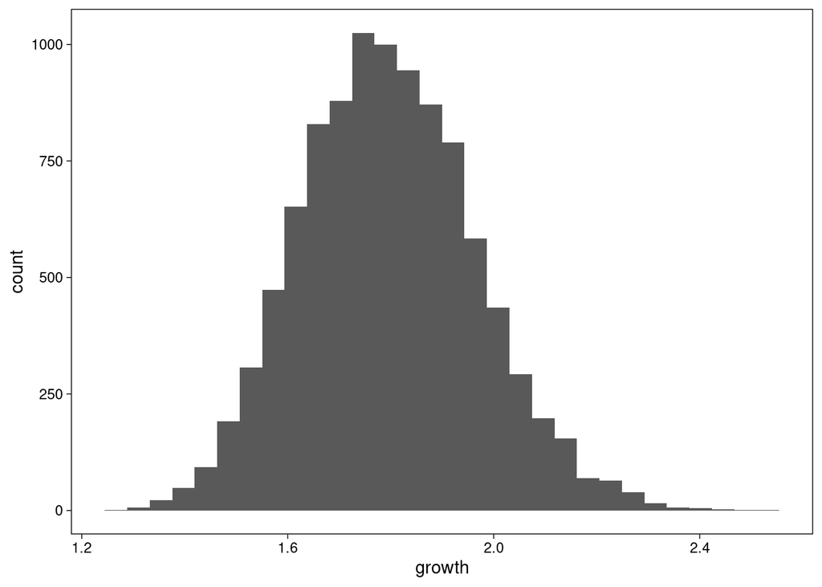

```r
#Distributions for multiplicative stuff:
big <- tibble(
  values = replicate(1000, prod(1 + runif(12, 0, 0.5)))
)
small <- tibble(
  values = replicate(1000, prod(1 + runif(12, 0, 0.1)))
)

#Another way of doing the same thing:
growth <- tibble(
  growth = map_dbl(1:1e4, ~prod(1 + runif(12, 0, 0.1)))
)

growth %>%
  ggplot(aes(x = growth))+
  geom_histogram(bins = 30)
```

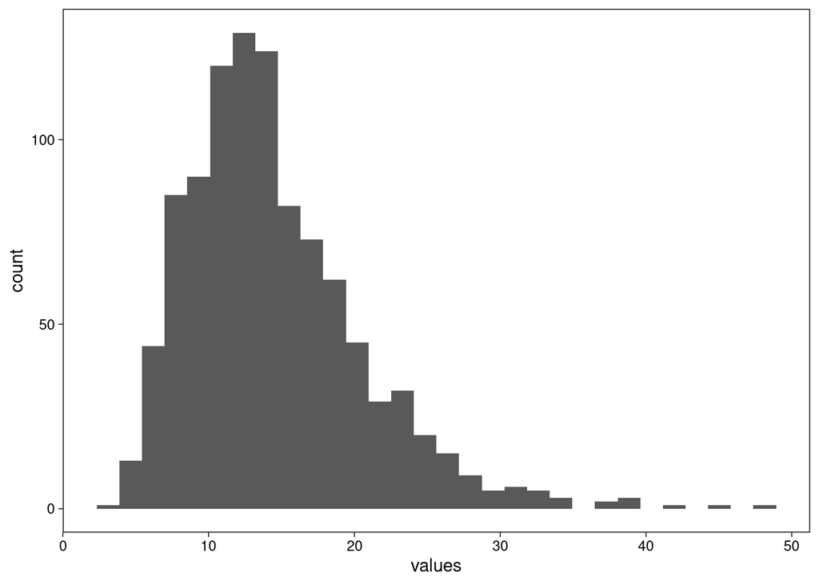

```r
big %>% ggplot(aes(x = values)) +geom_histogram(bins = 30)
```

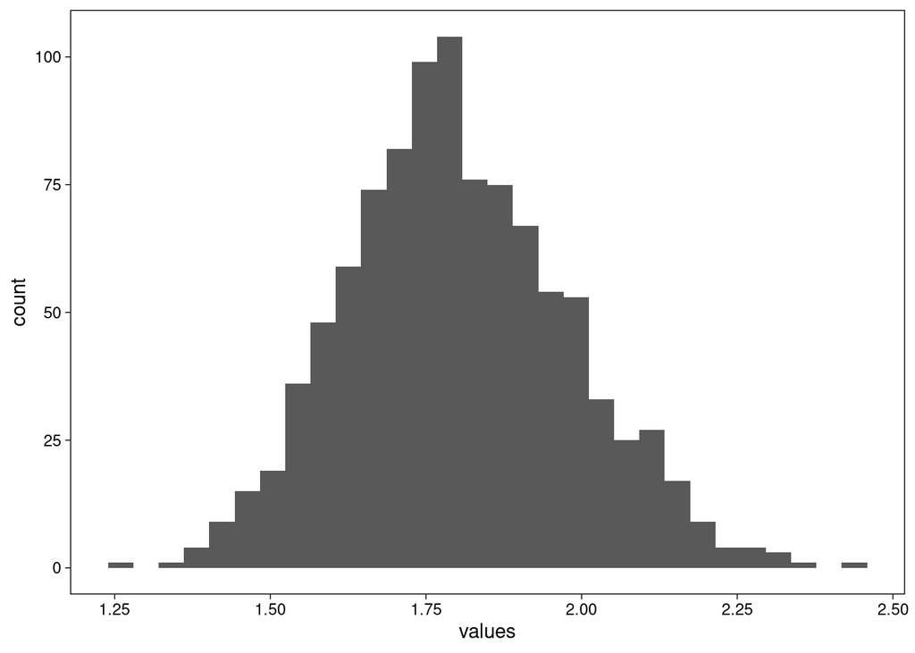

```r
small%>% ggplot(aes(x = values)) +geom_histogram(bins = 30)
```

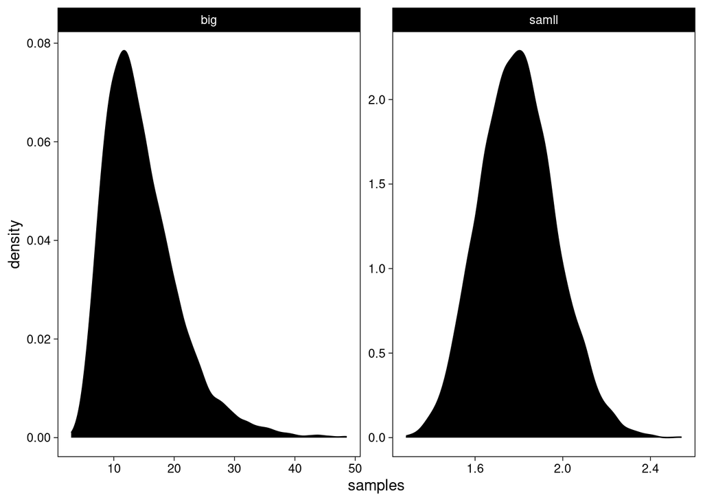

```r
#A different way of visualizing the same data.

samples <- tibble(
  big = map_dbl(1:1e4, ~prod(1+runif(12, 0, 0.5))),
  samll  =  map_dbl(1:1e4, ~prod(1+runif(12, 0, 0.1)))
)


samples %>%
  pivot_longer(everything(), values_to = "samples") %>%
  ggplot(aes(x = samples))+
  geom_density(fill = "black")+
  facet_wrap(~name, scales = "free")
```

A fantastic quote: These processes do this because at their heart, these processes add together fluctuations. And repeatedly adding finite fluctuations results in a distribution of sums that have shed all information about the underlying process, aside from mean and spread.

Gaussian Distribution is part of the *Exponential Family*.

Another Reason: When all we know or are willing to say about a distribution of measures (measures are continuous values on the real number line) is their mean and variance, then the Gaussian distribution arises as the most consistent with our assumptions.

A thing to understand: If, in light of the data and model, we approximate/estimate posterior plausibilities for a lot of mu and sigma values, in effect we are assigning posterior probabilities to a whole host of gaussian distributions, and ranking them as some more probable than others. In other words, it becomes a distribution of distributions.